# Question

En una empresa manufacturera, los empleados pueden trabajar cada semana en dos turnos: diurno y nocturno. Existen dos clasificaciones para los días de trabajo normales (de lunes a sábado) y dominicales. En el turno diurno del domingo se paga un 20% más que en el turno diurno de días normales. En el turno nocturno de un día cualquiera, la hora de trabajo se paga un 50% más que en el turno diurno de ese mismo día.

Un empleado laboró durante una semana 7 horas diurnas cada día. ¿Cuál es la gráfica que representa correctamente la proporción de dinero recibido cada día de la semana?

## Answerlist

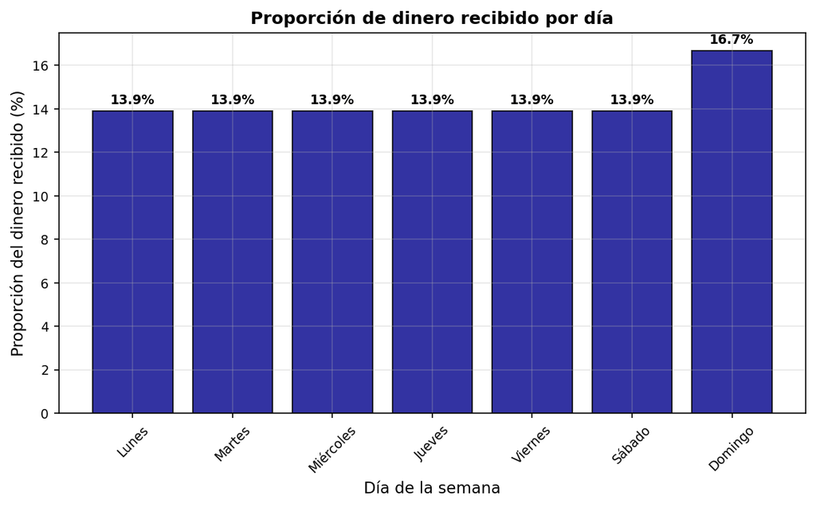

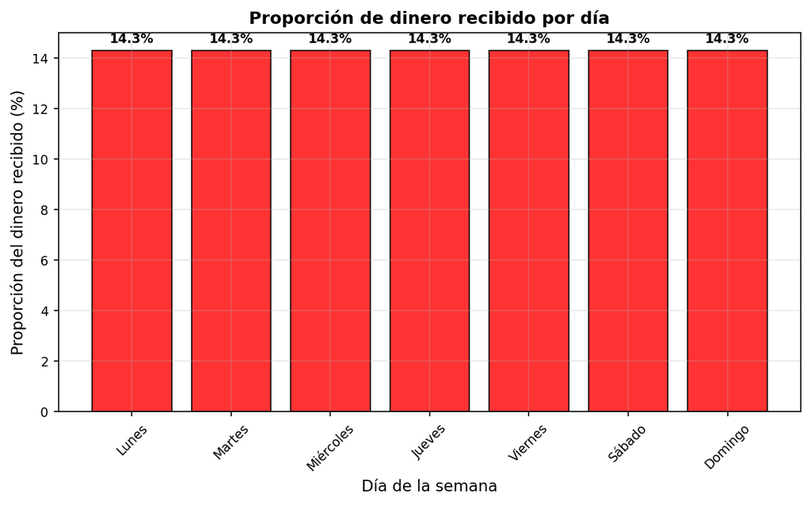

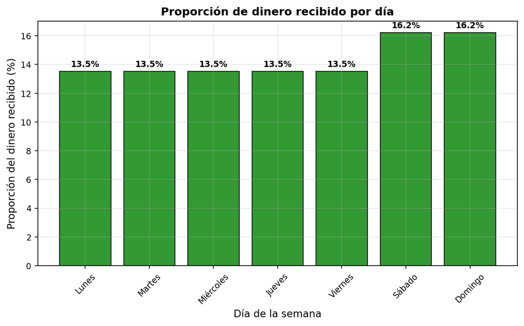

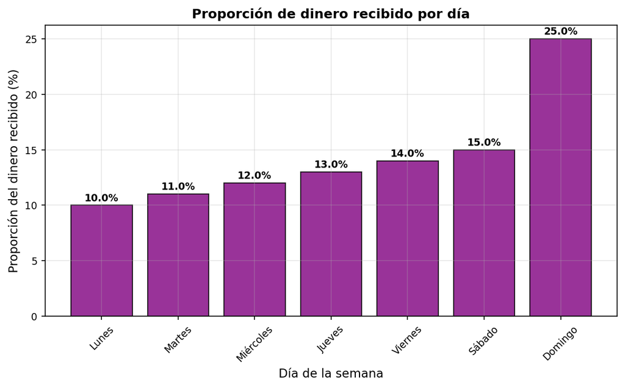

# Solution

Para resolver este problema, debemos calcular la proporción de dinero que recibe el trabajador cada día de la semana.

### Análisis del problema

**Condiciones de pago:**

- Turno diurno días normales (lunes a sábado): pago base
- Turno diurno domingo: pago base + 20%
- Turno nocturno cualquier día: pago diurno del día + 50%

**Datos del trabajador:**

- Trabajó 7 horas diurnas cada día
- Solo trabajó turnos diurnos (no nocturnos)

### Cálculo de proporciones

Si consideramos el pago base del turno diurno de días normales como 1 unidad:

**Pago por día:**

- Lunes a Sábado: 1 unidad cada día = 6 unidades
- Domingo: 1 + 20% = 1.2 unidades

**Total semanal:** 7.2 unidades

**Proporciones por día:** - Lunes: 13.9% - Martes: 13.9% - Miércoles: 13.9% - Jueves: 13.9% - Viernes: 13.9% - Sábado: 13.9% - Domingo: 16.7%

### Gráfica correcta

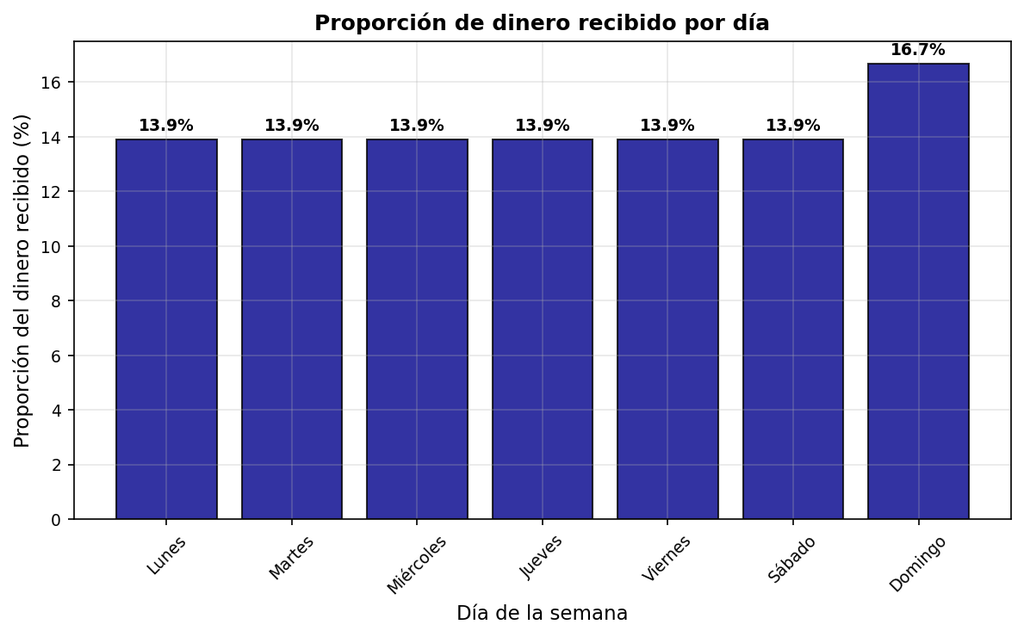

La gráfica correcta debe mostrar: - Lunes a Sábado: barras de igual altura (misma proporción aprox. 13.9%) - Domingo: barra más alta (proporción aprox. 16.7%)

## Answerlist

- Verdadero. Esta gráfica representa correctamente las proporciones calculadas.
- Falso. Esta gráfica muestra todos los días con la misma proporción, ignorando el pago extra del domingo.
- Falso. Esta gráfica incorrectamente asigna pago extra también al sábado.
- Falso. Esta gráfica muestra un patrón creciente que no corresponde a las condiciones del problema.

# Meta-information

exname: turnos_trabajo_proporciones_pago extype: schoice exsolution: 1000 exshuffle: TRUE exsection: Interpretación de gráficas - Proporciones laborales